# Difference Measures Explained

Nicholas Judd

4/26/2019

# Ways to measure change

For the last 50+ years statisticians have been debating over how to measure change when you only have two time points. Two main methods have developed, the residual-change method (ANCOVA) and the subtraction method. These notes look at bias in the residual-change model when the first timepoint (t1) is not randomized. This is quite common in psychology, epidemiology and ecology. Some recent literature that really helped me wrap my head around it was [Castro-Schilo & Grimm (2018)](https://journals.sagepub.com/doi/pdf/10.1177/0265407517718387) & van Breukelen(2006). Lots of the discussion centers around a categorical predictor (ANCOVA) yet this bias is also present when the data is continuous. See [*Simpson’s Paradox, Lord’s Paradox, and Suppression Effects are the same phenomenon–the reversal paradox*](https://ete-online.biomedcentral.com/articles/10.1186/1742-7622-5-2).

#### Residual-change model

${t2}_{i} \sim \alpha + \beta{t1}_{i} + \beta{IV}_{i}$  
#### Subtraction model  
$\Delta = t2 - t1$  
$\Delta_{i} \sim {PGS}_{i}$  
#### Things to do - Change name on legends, change colors for the two, and **make sure** they are consistant. - Write a small intro just discussing the two methods and you can relate them to their color for graphs.

## Benefits of residual change with randomized groups

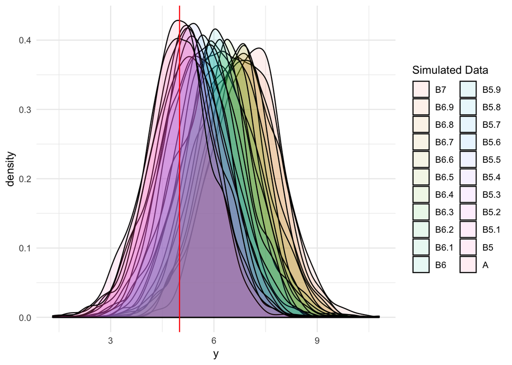

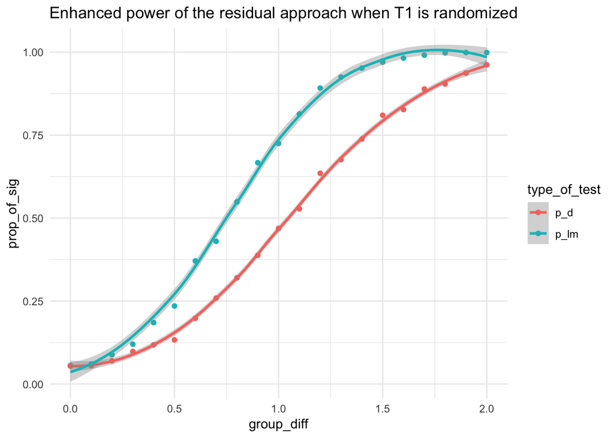

This is due to regression to the mean! (which is just a phenomenon that happens when you subtract 2 things)

```
##
## Call:
## lm(formula = d ~ t1, data = mat)
##
## Coefficients:
## (Intercept)           t1
##     0.01545     -1.11699
```

```
##
## Call:
## lm(formula = d ~ t2, data = mat)
##
## Coefficients:
## (Intercept)           t2
##   -0.002542     1.117201
```

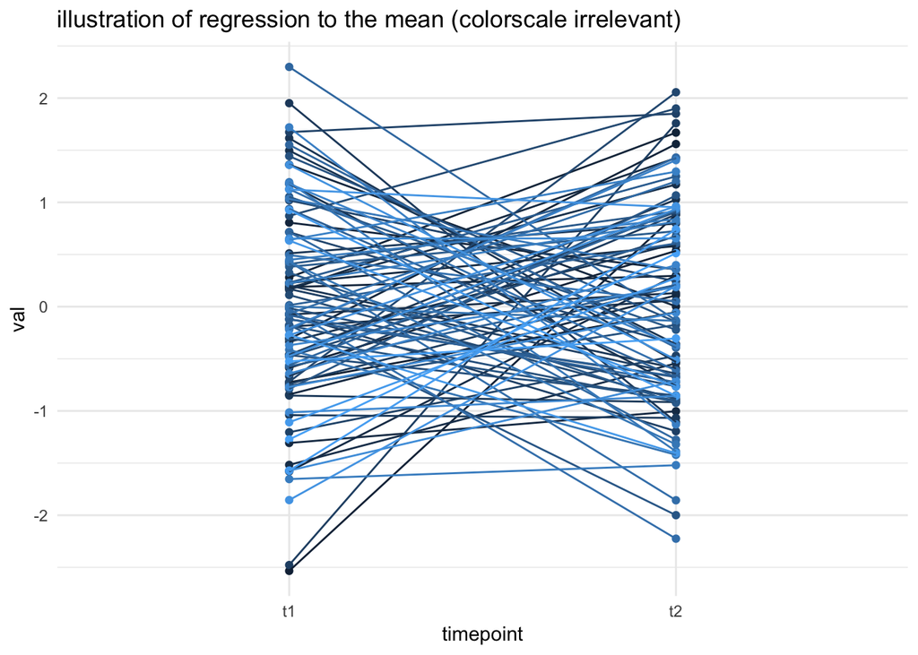

## Modifying the relationship between the covariate (t1) and the dependent variable (t2)

|  | t2 | t1 | PGS |
| --- | --- | --- | --- |
| t2 | 1 | x | 0.5 |
| t1 | x | 1 | 0.5 |
| PGS | 0.5 | 0.5 | 1.0 |

We are sampling from a multivariate normal probability distribution (see ?mvrnorm). This allows us to create multiple vectors of normally distrubted data with dependences (variance covariance matrix). All that is needed is the mean’s, variances and corresponding covariances of the normally distributed data you would like to simulate.

It makes logical sense to first see how the two methods develop when modifying the realtionship of T1 with T2, while holding the relationships of t2 with pgs and t1 with pgs constant (in this example 0.5). To the right you can see the *emperical* variance-covariance matrix, this of course changes with each simulation as we are drawing values from a density distribution. The value “x” represents the covariance we are modifying.

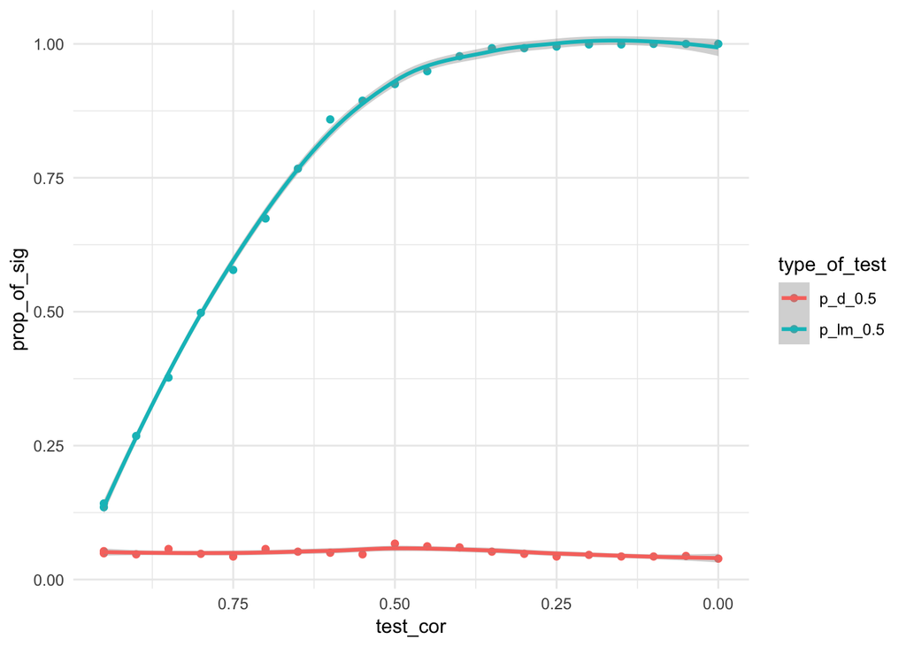

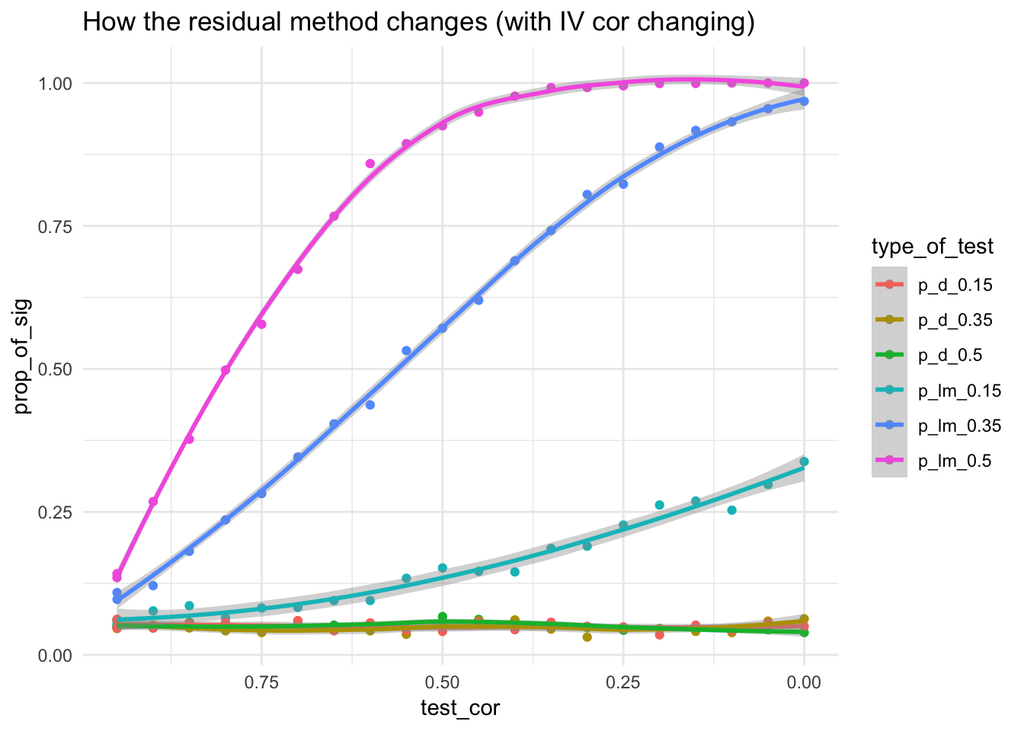

## Simulating a rich get richer effect

In this example I am simulated multivariate normal data for only t1 and the PGS, changing the correlation between these two values. I than multiply t1 times 2 and add a bit of noise to simulate a rich get richer effect. Ofcourse this preserves the intial t1 correlation with PGS for t2.

Here is a plot of one simulation of rich get richer effects.

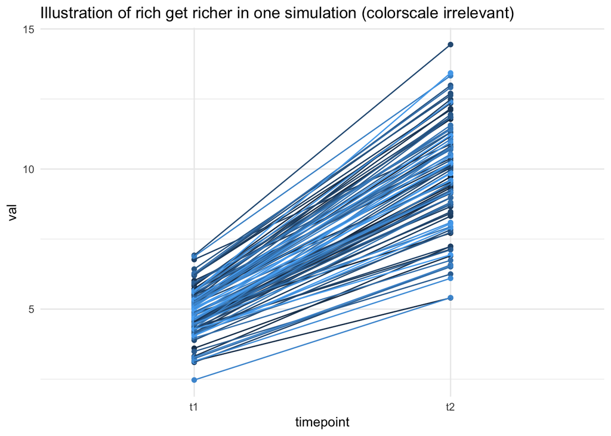

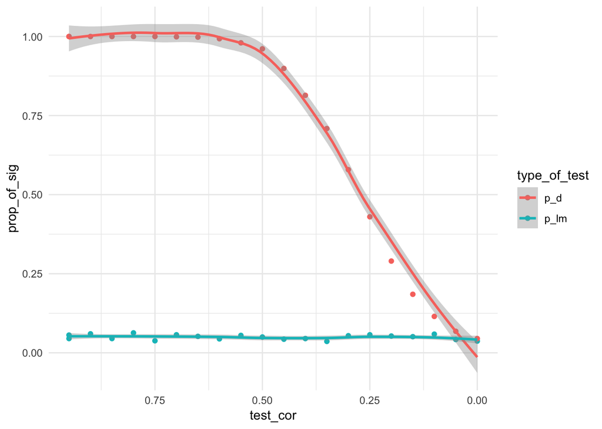

#### Other situations, hidden code

```r
# this simulation ignores that you are sampling from a probability distribution
# therefore each time you run it is will give you different results
# futhermore there is a forcing of dependence

for (i in seq(0.1,1, 0.1)){
  PGS <- rnorm(1000,1)
  t1 <- i*PGS + rnorm(1000,1)
  t2 <- 0.3 + 1.2*t1 + 0.1*PGS + rnorm(1000,1)
  print(i)
  dat_tk <- data.frame( t2 = t2, t1 = t1, PGS = PGS)
  #print(cov(dat_tk))
  #print(cor(dat_tk))
  #print(summary(lm(t2 ~ t1*PGS), data = dat_tk))
}
```